```python
# Importation des bibliothèques
import pandas as pd
import numpy as np
import matplotlib.pyplot as plt
import seaborn as sns

# Paramètres d'affichage
pd.set_option('display.max_columns', None)
pd.set_option('display.float_format', lambda x: '%.2f' % x)
plt.rcParams['figure.figsize'] = (12, 5)

print("✅ Bibliothèques importées avec succès")
```

```
✅ Bibliothèques importées avec succès
```

# Analyse exploratoire — E-commerce France / Women 2023–2024

## Contexte

Ce notebook réalise l'analyse exploratoire (EDA) du sous-périmètre e-commerce :

- **Pays** : France
- **Département** : Women
- **Période** : 01/01/2023 → 31/12/2024

## Plan

1. Chargement et description des données
2. Contrôles qualité
3. Analyse descriptive
4. Comparaison 2023 vs 2024
5. Calcul des KPIs

## 1. Chargement et description des données

```python
# Chargement du CSV
df = pd.read_csv('../data/thelook_fr_women_2023_2024.csv')

# Dimensions du DataFrame
print(f"Nombre de lignes    : {df.shape[0]:,}")
print(f"Nombre de colonnes  : {df.shape[1]}")
print(f"\nAperçu des premières lignes :")
df.head()
```

```
Nombre de lignes    : 1,679
Nombre de colonnes  : 20

Aperçu des premières lignes :
```

|  | order_id | order_item_id | product_id | item_created_at | item_status | sale_price | cost | category | department | brand | product_name | order_status | order_created_at | shipped_at | delivered_at | user_id | gender | country | state | city |
| --- | --- | --- | --- | --- | --- | --- | --- | --- | --- | --- | --- | --- | --- | --- | --- | --- | --- | --- | --- | --- |
| 0 | 19425 | 28112 | 6983 | 2023-01-01 06:18:03+00:00 | Shipped | 29.50 | 16.05 | Shorts | Women | Fox | Fox Juniors Momentum Short | Shipped | 2022-12-29 10:00:00+00:00 | 2022-12-30 11:29:00+00:00 | NaN | 15644 | F | France | Centre-Val de Loire | Corquilleroy |
| 1 | 19425 | 28113 | 10597 | 2023-01-01 06:44:58+00:00 | Shipped | 20.00 | 10.00 | Intimates | Women | Wacoal | Wacoal Women's B-Smooth Bralette | Shipped | 2022-12-29 10:00:00+00:00 | 2022-12-30 11:29:00+00:00 | NaN | 15644 | F | France | Centre-Val de Loire | Corquilleroy |
| 2 | 4710 | 6730 | 11792 | 2023-01-03 04:44:50+00:00 | Complete | 38.00 | 18.47 | Intimates | Women | American Apparel | American Apparel Striped Chiffon Tank | Complete | 2023-01-03 08:12:00+00:00 | 2023-01-03 09:14:00+00:00 | 2023-01-04 03:03:00+00:00 | 3853 | F | France | Île-de-France | Paris |
| 3 | 16618 | 24006 | 329 | 2023-01-03 15:13:39+00:00 | Complete | 27.99 | 16.40 | Tops & Tees | Women | Tri-Mountain | Tri-Mountain Women's 3/4-Sleeve Pique Knit Pol... | Complete | 2023-01-03 18:58:00+00:00 | 2023-01-05 13:23:00+00:00 | 2023-01-09 10:25:00+00:00 | 13422 | F | France | Hauts-de-France | Comines |
| 4 | 4710 | 6731 | 5295 | 2023-01-05 06:43:09+00:00 | Complete | 56.88 | 29.58 | Pants & Capris | Women | Lauren by Ralph Lauren | Lauren Ralph Lauren Velour Pants | Complete | 2023-01-03 08:12:00+00:00 | 2023-01-03 09:14:00+00:00 | 2023-01-04 03:03:00+00:00 | 3853 | F | France | Île-de-France | Paris |

```python
# Description des colonnes
print("Colonnes du DataFrame :")
print(df.columns.tolist())
```

```
Colonnes du DataFrame :
['order_id', 'order_item_id', 'product_id', 'item_created_at', 'item_status', 'sale_price', 'cost', 'category', 'department', 'brand', 'product_name', 'order_status', 'order_created_at', 'shipped_at', 'delivered_at', 'user_id', 'gender', 'country', 'state', 'city']
```

```python
# Affichage complet des colonnes
for i, col in enumerate(df.columns):
    print(f"{i+1:2}. {col}")
```

```
 1. order_id
 2. order_item_id
 3. product_id
 4. item_created_at
 5. item_status
 6. sale_price
 7. cost
 8. category
 9. department
10. brand
11. product_name
12. order_status
13. order_created_at
14. shipped_at
15. delivered_at
16. user_id
17. gender
18. country
19. state
20. city
```

### Dictionnaire de données

```python
# Dictionnaire de données
dictionnaire = {
    'Colonne': [
        'order_id', 'order_item_id', 'product_id', 'item_created_at',
        'item_status', 'sale_price', 'cost', 'category', 'department',
        'brand', 'product_name', 'order_status', 'order_created_at',
        'shipped_at', 'delivered_at', 'user_id', 'gender', 'country',
        'state', 'city'
    ],
    'Type': [
        'int', 'int', 'int', 'datetime',
        'str', 'float', 'float', 'str', 'str',
        'str', 'str', 'str', 'datetime',
        'datetime', 'datetime', 'int', 'str', 'str',
        'str', 'str'
    ],
    'Description': [
        'Identifiant unique de la commande',
        'Identifiant unique de la ligne de commande',
        'Identifiant unique du produit',
        'Date de création de la ligne article',
        'Statut de la ligne article (Complete, Returned...)',
        'Prix de vente du produit (€)',
        'Coût d\'achat du produit (€)',
        'Catégorie du produit (Tops & Tees, Pants...)',
        'Département (Women)',
        'Marque du produit',
        'Nom complet du produit',
        'Statut global de la commande',
        'Date de création de la commande',
        'Date d\'expédition',
        'Date de livraison',
        'Identifiant unique du client',
        'Genre du client',
        'Pays du client',
        'Région/État du client',
        'Ville du client'
    ]
}

pd.DataFrame(dictionnaire)
```

|  | Colonne | Type | Description |
| --- | --- | --- | --- |
| 0 | order_id | int | Identifiant unique de la commande |
| 1 | order_item_id | int | Identifiant unique de la ligne de commande |
| 2 | product_id | int | Identifiant unique du produit |
| 3 | item_created_at | datetime | Date de création de la ligne article |
| 4 | item_status | str | Statut de la ligne article (Complete, Returned... |
| 5 | sale_price | float | Prix de vente du produit (€) |
| 6 | cost | float | Coût d'achat du produit (€) |
| 7 | category | str | Catégorie du produit (Tops & Tees, Pants...) |
| 8 | department | str | Département (Women) |
| 9 | brand | str | Marque du produit |
| 10 | product_name | str | Nom complet du produit |
| 11 | order_status | str | Statut global de la commande |
| 12 | order_created_at | datetime | Date de création de la commande |
| 13 | shipped_at | datetime | Date d'expédition |
| 14 | delivered_at | datetime | Date de livraison |
| 15 | user_id | int | Identifiant unique du client |
| 16 | gender | str | Genre du client |
| 17 | country | str | Pays du client |
| 18 | state | str | Région/État du client |
| 19 | city | str | Ville du client |

```python
dictionnaire['Exemple'] = [
    '19425', '28112', '6983', '2023-01-01 06:18:03',
    'Shipped', '29.50', '16.05', 'Shorts', 'Women',
    'Fox', 'Fox Juniors Momentum Short', 'Shipped', '2022-12-29 10:00:00',
    '2022-12-30 11:29:00', 'NaT (non livré)', '15644', 'F', 'France',
    'Centre-Val de Loire', 'Corquilleroy'
]
pd.DataFrame(dictionnaire)
```

|  | Colonne | Type | Description | Exemple |
| --- | --- | --- | --- | --- |
| 0 | order_id | int | Identifiant unique de la commande | 19425 |
| 1 | order_item_id | int | Identifiant unique de la ligne de commande | 28112 |
| 2 | product_id | int | Identifiant unique du produit | 6983 |
| 3 | item_created_at | datetime | Date de création de la ligne article | 2023-01-01 06:18:03 |
| 4 | item_status | str | Statut de la ligne article (Complete, Returned... | Shipped |
| 5 | sale_price | float | Prix de vente du produit (€) | 29.50 |
| 6 | cost | float | Coût d'achat du produit (€) | 16.05 |
| 7 | category | str | Catégorie du produit (Tops & Tees, Pants...) | Shorts |
| 8 | department | str | Département (Women) | Women |
| 9 | brand | str | Marque du produit | Fox |
| 10 | product_name | str | Nom complet du produit | Fox Juniors Momentum Short |
| 11 | order_status | str | Statut global de la commande | Shipped |
| 12 | order_created_at | datetime | Date de création de la commande | 2022-12-29 10:00:00 |
| 13 | shipped_at | datetime | Date d'expédition | 2022-12-30 11:29:00 |
| 14 | delivered_at | datetime | Date de livraison | NaT (non livré) |
| 15 | user_id | int | Identifiant unique du client | 15644 |
| 16 | gender | str | Genre du client | F |
| 17 | country | str | Pays du client | France |
| 18 | state | str | Région/État du client | Centre-Val de Loire |
| 19 | city | str | Ville du client | Corquilleroy |

## 2. Contrôles qualité

```python
# Types réels et valeurs manquantes
print("=== TYPES ET VALEURS MANQUANTES ===\n")
info = pd.DataFrame({
    'Type réel': df.dtypes,
    'Valeurs manquantes': df.isnull().sum(),
    '% manquant': (df.isnull().sum() / len(df) * 100).round(2)
})
print(info)
```

```
=== TYPES ET VALEURS MANQUANTES ===

                 Type réel  Valeurs manquantes  % manquant
order_id             int64                   0        0.00
order_item_id        int64                   0        0.00
product_id           int64                   0        0.00
item_created_at        str                   0        0.00
item_status            str                   0        0.00
sale_price         float64                   0        0.00
cost               float64                   0        0.00
category               str                   0        0.00
department             str                   0        0.00
brand                  str                   2        0.12
product_name           str                   0        0.00
order_status           str                   0        0.00
order_created_at       str                   0        0.00
shipped_at             str                 546       32.52
delivered_at           str                1043       62.12
user_id              int64                   0        0.00
gender                 str                   0        0.00
country                str                   0        0.00
state                  str                   0        0.00
city                   str                   0        0.00
```

```python
# Conversion des dates en datetime
date_cols = ['item_created_at', 'order_created_at', 'shipped_at', 'delivered_at']
for col in date_cols:
    df[col] = pd.to_datetime(df[col], utc=True)

# Vérification des doublons
doublons = df.duplicated().sum()

print("=== CONTRÔLE QUALITÉ ===\n")
print(f"✅ Dates converties en datetime : {date_cols}")
print(f"✅ Doublons détectés : {doublons}")
print(f"\nTypes après conversion :")
print(df[date_cols].dtypes)
```

```
=== CONTRÔLE QUALITÉ ===

✅ Dates converties en datetime : ['item_created_at', 'order_created_at', 'shipped_at', 'delivered_at']
✅ Doublons détectés : 0

Types après conversion :
item_created_at     datetime64[us, UTC]
order_created_at    datetime64[us, UTC]
shipped_at          datetime64[us, UTC]
delivered_at        datetime64[us, UTC]
dtype: object
```

```python
# Vérification de la cohérence des périodes
print("=== COHÉRENCE DES PÉRIODES ===\n")
print(f"Date min : {df['item_created_at'].min()}")
print(f"Date max : {df['item_created_at'].max()}")
print(f"\nRépartition par année :")
print(df['item_created_at'].dt.year.value_counts().sort_index())
print(f"\nStatuts présents :")
print(df['item_status'].value_counts())
```

```
=== COHÉRENCE DES PÉRIODES ===

Date min : 2023-01-01 06:18:03+00:00
Date max : 2024-12-31 10:40:48+00:00

Répartition par année :
item_created_at
2023    711
2024    968
Name: count, dtype: int64

Statuts présents :
item_status
Shipped       497
Complete      425
Processing    306
Cancelled     240
Returned      211
Name: count, dtype: int64
```

```python
# Commentaire explicite sur les conventions appliquées
print("=== CONVENTION MÉTIER APPLIQUÉE ===\n")

df_ventes = df[df['item_status'] == 'Complete']
df_retours = df[df['item_status'] == 'Returned']

print(f"Lignes 'Complete' (ventes) : {len(df_ventes)}")
print(f"Lignes 'Returned' (retours) : {len(df_retours)}")
print(f"Lignes exclues des KPI      : {len(df) - len(df_ventes) - len(df_retours)}")
print(f"\n✅ Périmètre KPI = {len(df_ventes) + len(df_retours)} lignes sur {len(df)} au total")
```

```
=== CONVENTION MÉTIER APPLIQUÉE ===

Lignes 'Complete' (ventes) : 425
Lignes 'Returned' (retours) : 211
Lignes exclues des KPI      : 1043

✅ Périmètre KPI = 636 lignes sur 1679 au total
```

## 3. Analyse descriptive

### Distribution des prix de vente et des coûts

```python
# Statistiques descriptives sur les prix et coûts (lignes Complete uniquement)
print("=== STATISTIQUES DESCRIPTIVES ===\n")
stats = df_ventes[['sale_price', 'cost']].describe().round(2)
stats.loc['marge_moyenne'] = (df_ventes['sale_price'] - df_ventes['cost']).describe().round(2)
print(stats)
```

```
=== STATISTIQUES DESCRIPTIVES ===

               sale_price   cost
count              425.00 425.00
mean                55.35  26.62
std                 71.41  33.70
min                  1.82   0.75
25%                 18.97   8.74
50%                 36.29  17.97
75%                 62.36  29.58
max                903.00 437.05
marge_moyenne         NaN    NaN
```

```python
# Statistiques corrigées + marge
print("=== STATISTIQUES DESCRIPTIVES ===\n")

stats = df_ventes[['sale_price', 'cost']].describe().round(2)
print(stats)

marge = df_ventes['sale_price'] - df_ventes['cost']
print(f"\n=== MARGE BRUTE PAR ARTICLE ===")
print(f"Marge moyenne  : {marge.mean():.2f} €")
print(f"Marge médiane  : {marge.median():.2f} €")
print(f"Marge min      : {marge.min():.2f} €")
print(f"Marge max      : {marge.max():.2f} €")
```

```
=== STATISTIQUES DESCRIPTIVES ===

       sale_price   cost
count      425.00 425.00
mean        55.35  26.62
std         71.41  33.70
min          1.82   0.75
25%         18.97   8.74
50%         36.29  17.97
75%         62.36  29.58
max        903.00 437.05

=== MARGE BRUTE PAR ARTICLE ===
Marge moyenne  : 28.73 €
Marge médiane  : 18.47 €
Marge min      : 1.07 €
Marge max      : 465.95 €
```

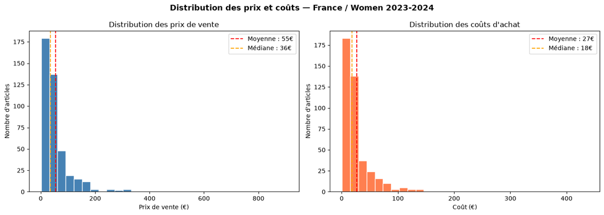

```
✅ Graphique sauvegardé
```

```python
# Distribution des prix et coûts
fig, axes = plt.subplots(1, 2, figsize=(14, 5))

# Prix de vente
axes[0].hist(df_ventes['sale_price'], bins=30, color='steelblue', edgecolor='white')
axes[0].axvline(df_ventes['sale_price'].mean(), color='red', linestyle='--', label=f"Moyenne : {df_ventes['sale_price'].mean():.0f}€")
axes[0].axvline(df_ventes['sale_price'].median(), color='orange', linestyle='--', label=f"Médiane : {df_ventes['sale_price'].median():.0f}€")
axes[0].set_title("Distribution des prix de vente")
axes[0].set_xlabel("Prix de vente (€)")
axes[0].set_ylabel("Nombre d'articles")
axes[0].legend()

# Coût
axes[1].hist(df_ventes['cost'], bins=30, color='coral', edgecolor='white')
axes[1].axvline(df_ventes['cost'].mean(), color='red', linestyle='--', label=f"Moyenne : {df_ventes['cost'].mean():.0f}€")
axes[1].axvline(df_ventes['cost'].median(), color='orange', linestyle='--', label=f"Médiane : {df_ventes['cost'].median():.0f}€")
axes[1].set_title("Distribution des coûts d'achat")
axes[1].set_xlabel("Coût (€)")
axes[1].set_ylabel("Nombre d'articles")
axes[1].legend()

plt.suptitle("Distribution des prix et coûts — France / Women 2023-2024", fontsize=13, fontweight='bold')
plt.tight_layout()
plt.savefig('../data/viz_distribution_prix_couts.png', dpi=150, bbox_inches='tight')
plt.show()
print("✅ Graphique sauvegardé")
```

**Constats :**

- La majorité des articles vendus ont un prix inférieur à 200€
- La distribution est asymétrique à droite : quelques articles premium (jusqu'à 903€) tirent la moyenne au-dessus de la médiane
- Même observation sur les coûts : la médiane (18€) est bien inférieure à la moyenne (27€)
- La marge brute moyenne est de 28.73€ par article, mais la médiane n'est que de 18.47€

**Vision métier :**

- Le prix "typique" d'un article est de 36€ (médiane) — c'est ce chiffre à communiquer à la direction, pas la moyenne biaisée par les articles premium
- Les articles à plus de 200€ sont rares mais peuvent représenter une part significative du CA — à analyser
- Surveiller les articles à faible marge (min 1.07€) : sont-ils rentables après frais logistiques ?

**Choix du graphique :**

- **Histogramme** choisi pour visualiser la distribution d'une variable continue
- Les lignes moyenne/médiane permettent de repérer immédiatement l'asymétrie
- Alternative possible : boxplot (meilleure lisibilité des outliers)

### Contribution par marque

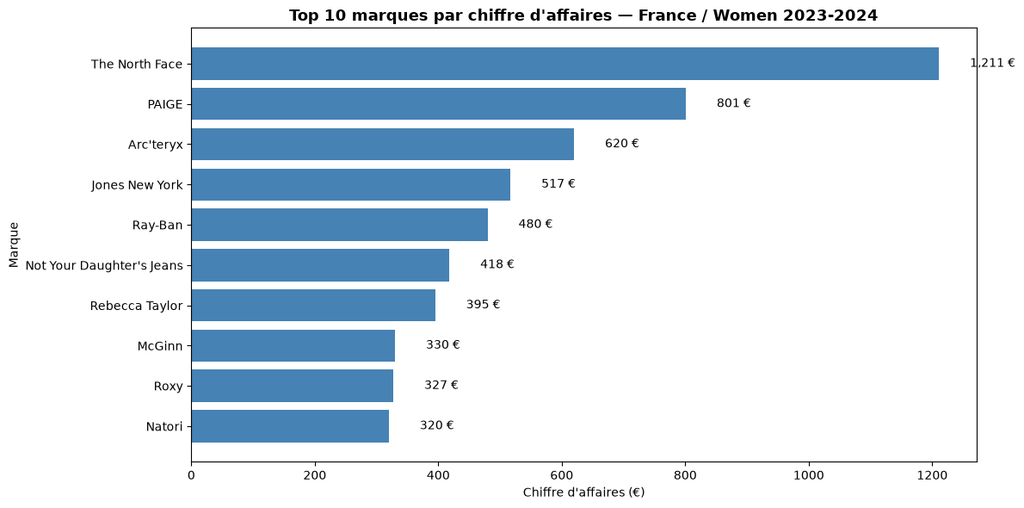

```
✅ Graphique sauvegardé
```

```python
# Contribution par marque (sur lignes Complete uniquement)
ca_marque = df_ventes.groupby('brand')['sale_price'].sum().sort_values(ascending=False).head(10)

fig, ax = plt.subplots(figsize=(12, 6))
bars = ax.barh(ca_marque.index[::-1], ca_marque.values[::-1], color='steelblue')

# Ajout des valeurs sur les barres
for bar, val in zip(bars, ca_marque.values[::-1]):
    ax.text(bar.get_width() + 50, bar.get_y() + bar.get_height()/2,
            f'{val:,.0f} €', va='center', fontsize=10)

ax.set_title("Top 10 marques par chiffre d'affaires — France / Women 2023-2024",
             fontsize=13, fontweight='bold')
ax.set_xlabel("Chiffre d'affaires (€)")
ax.set_ylabel("Marque")
plt.tight_layout()
plt.savefig('../data/viz_contribution_marques.png', dpi=150, bbox_inches='tight')
plt.show()
print("✅ Graphique sauvegardé")
```

**Vision métier :**

- Renforcer les partenariats avec The North Face et PAIGE qui génèrent le plus de valeur
- Surveiller les marques du bas du classement : sont-elles rentables ou à déréférencer ?

**Choix du graphique :**

- **Barres horizontales** choisies car les noms de marques sont longs — plus lisible qu'un graphique vertical
- Permet de comparer facilement les marques entre elles et de voir le classement d'un coup d'œil
- Alternative possible : camembert (part de marché), mais moins lisible avec 10 marques

### Contribution par catégorie

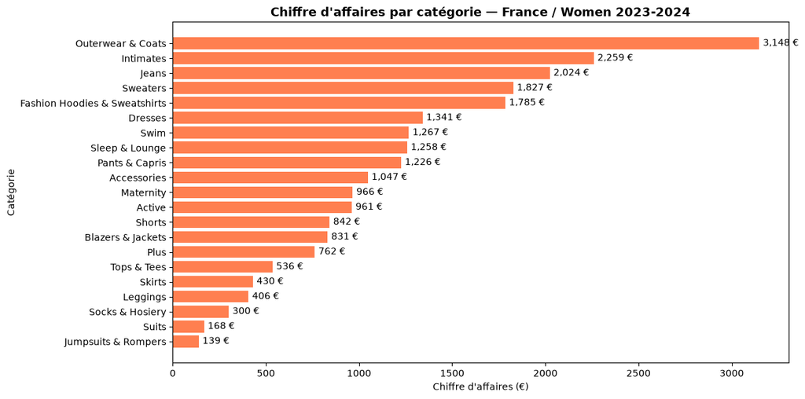

```
✅ Graphique sauvegardé
```

```python
# Contribution par catégorie (sur lignes Complete uniquement)
ca_categorie = df_ventes.groupby('category')['sale_price'].sum().sort_values(ascending=False)

fig, ax = plt.subplots(figsize=(12, 6))
bars = ax.barh(ca_categorie.index[::-1], ca_categorie.values[::-1], color='coral')

# Ajout des valeurs sur les barres
for bar, val in zip(bars, ca_categorie.values[::-1]):
    ax.text(bar.get_width() + 20, bar.get_y() + bar.get_height()/2,
            f'{val:,.0f} €', va='center', fontsize=10)

ax.set_title("Chiffre d'affaires par catégorie — France / Women 2023-2024",
             fontsize=13, fontweight='bold')
ax.set_xlabel("Chiffre d'affaires (€)")
ax.set_ylabel("Catégorie")
plt.tight_layout()
plt.savefig('../data/viz_contribution_categories.png', dpi=150, bbox_inches='tight')
plt.show()
print("✅ Graphique sauvegardé")
```

**Vision métier :**

- Concentrer les efforts marketing sur Outerwear, Intimates et Jeans — ce sont les moteurs de croissance
- Analyser la rentabilité des catégories en bas de classement : à développer ou à déréférencer ?
- La présence de Maternity (966€) indique un segment clientèle spécifique à ne pas négliger

**Choix du graphique :**

- **Barres horizontales** pour les mêmes raisons que les marques — noms de catégories longs
- Toutes les catégories affichées (pas de top 10) pour avoir une vue exhaustive du catalogue
- Alternative possible : treemap pour visualiser les parts relatives, mais moins précis pour comparer les valeurs

### Contribution par ville

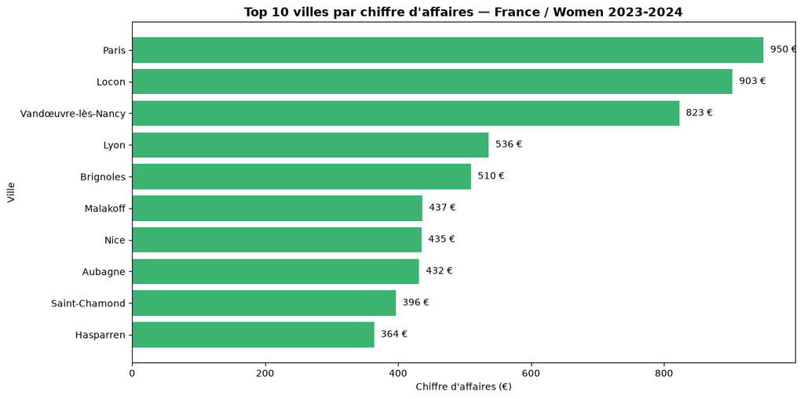

```
✅ Graphique sauvegardé
```

```python
# Contribution par ville - Top 10 (sur lignes Complete uniquement)
ca_ville = df_ventes.groupby('city')['sale_price'].sum().sort_values(ascending=False).head(10)

fig, ax = plt.subplots(figsize=(12, 6))
bars = ax.barh(ca_ville.index[::-1], ca_ville.values[::-1], color='mediumseagreen')

# Ajout des valeurs sur les barres
for bar, val in zip(bars, ca_ville.values[::-1]):
    ax.text(bar.get_width() + 10, bar.get_y() + bar.get_height()/2,
            f'{val:,.0f} €', va='center', fontsize=10)

ax.set_title("Top 10 villes par chiffre d'affaires — France / Women 2023-2024",
             fontsize=13, fontweight='bold')
ax.set_xlabel("Chiffre d'affaires (€)")
ax.set_ylabel("Ville")
plt.tight_layout()
plt.savefig('../data/viz_contribution_villes.png', dpi=150, bbox_inches='tight')
plt.show()
print("✅ Graphique sauvegardé")
```

**Constats :**

- Paris domine le CA avec 950€, suivi de façon surprenante par Locon (903€) et Vandœuvre-lès-Nancy (823€)
- Lyon, 2ème ville de France, n'arrive qu'en 4ème position (536€) — sous-performance notable
- Forte présence du Sud-Est : Nice, Aubagne, Brignoles dans le top 10
- Les écarts entre villes sont importants : Paris fait presque 3x le CA de Hasparren

**Vision métier :**

- Locon et Vandœuvre-lès-Nancy méritent une attention particulière : pourquoi surperforment-elles ? Profil client spécifique ? Quelques gros acheteurs ?
- Lyon représente un potentiel de croissance important — ville sous-exploitée par rapport à sa taille
- Envisager des campagnes marketing ciblées sur le Sud-Est qui montre une forte concentration de clientes

**Choix du graphique :**

- **Barres horizontales** pour la lisibilité des noms de villes
- Top 10 choisi pour rester lisible — afficher toutes les villes noierait l'information
- Alternative possible : carte géographique (choroplèthe) pour une vision spatiale — réalisée dans Power BI

### Saisonnalité mensuelle

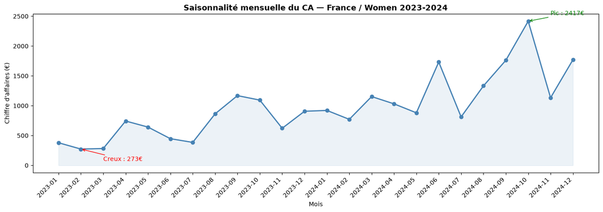

```
✅ Graphique sauvegardé
```

```python
# Saisonnalité mensuelle du CA (lignes Complete uniquement)
df_ventes = df_ventes.copy()
df_ventes['mois'] = df_ventes['item_created_at'].dt.to_period('M')
ca_mensuel = df_ventes.groupby('mois')['sale_price'].sum().reset_index()
ca_mensuel['mois_str'] = ca_mensuel['mois'].astype(str)

fig, ax = plt.subplots(figsize=(14, 5))
ax.plot(ca_mensuel['mois_str'], ca_mensuel['sale_price'],
        marker='o', color='steelblue', linewidth=2, markersize=6)
ax.fill_between(range(len(ca_mensuel)), ca_mensuel['sale_price'],
                alpha=0.1, color='steelblue')

# Annoter les pics et creux
max_idx = ca_mensuel['sale_price'].idxmax()
min_idx = ca_mensuel['sale_price'].idxmin()
ax.annotate(f"Pic : {ca_mensuel.loc[max_idx, 'sale_price']:.0f}€",
            xy=(max_idx, ca_mensuel.loc[max_idx, 'sale_price']),
            xytext=(max_idx+1, ca_mensuel.loc[max_idx, 'sale_price']+100),
            arrowprops=dict(arrowstyle='->', color='green'), color='green', fontsize=10)
ax.annotate(f"Creux : {ca_mensuel.loc[min_idx, 'sale_price']:.0f}€",
            xy=(min_idx, ca_mensuel.loc[min_idx, 'sale_price']),
            xytext=(min_idx+1, ca_mensuel.loc[min_idx, 'sale_price']-200),
            arrowprops=dict(arrowstyle='->', color='red'), color='red', fontsize=10)

ax.set_title("Saisonnalité mensuelle du CA — France / Women 2023-2024",
             fontsize=13, fontweight='bold')
ax.set_xlabel("Mois")
ax.set_ylabel("Chiffre d'affaires (€)")
ax.set_xticks(range(len(ca_mensuel)))
ax.set_xticklabels(ca_mensuel['mois_str'], rotation=45, ha='right')
plt.tight_layout()
plt.savefig('../data/viz_saisonnalite.png', dpi=150, bbox_inches='tight')
plt.show()
print("✅ Graphique sauvegardé")
```

**Constats :**

- Creux historique en février 2023 (273€) — mois typiquement faible dans le retail mode
- Tendance générale haussière sur 2023-2024 : le CA progresse globalement
- Pic visible en octobre 2024 → cohérent avec les achats automne/hiver (Outerwear & Coats)
- Forte volatilité mensuelle : le CA peut doubler ou tripler d'un mois à l'autre

**Vision métier :**

- Anticiper le pic d'octobre : s'assurer du stock suffisant en Outerwear & Coats dès septembre
- Animer le mois de février (creux) avec des promotions pour lisser la saisonnalité
- La croissance 2023→2024 est un signal positif à quantifier dans la section suivante

## 4. Comparaison 2023 vs 2024

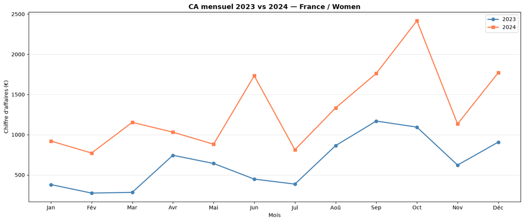

```
✅ Graphique sauvegardé
```

```python
# Séries mensuelles 2023 vs 2024
df_ventes['annee'] = df_ventes['item_created_at'].dt.year
df_ventes['mois_num'] = df_ventes['item_created_at'].dt.month

ca_2023 = df_ventes[df_ventes['annee'] == 2023].groupby('mois_num')['sale_price'].sum()
ca_2024 = df_ventes[df_ventes['annee'] == 2024].groupby('mois_num')['sale_price'].sum()

mois_labels = ['Jan', 'Fév', 'Mar', 'Avr', 'Mai', 'Jun',
               'Jul', 'Aoû', 'Sep', 'Oct', 'Nov', 'Déc']

fig, ax = plt.subplots(figsize=(14, 6))
ax.plot(mois_labels, ca_2023.reindex(range(1,13), fill_value=0),
        marker='o', color='steelblue', linewidth=2, label='2023')
ax.plot(mois_labels, ca_2024.reindex(range(1,13), fill_value=0),
        marker='s', color='coral', linewidth=2, label='2024')

ax.set_title("CA mensuel 2023 vs 2024 — France / Women",
             fontsize=13, fontweight='bold')
ax.set_xlabel("Mois")
ax.set_ylabel("Chiffre d'affaires (€)")
ax.legend()
ax.grid(axis='y', alpha=0.3)
plt.tight_layout()
plt.savefig('../data/viz_ca_2023_vs_2024.png', dpi=150, bbox_inches='tight')
plt.show()
print("✅ Graphique sauvegardé")
```

```python
# Écarts absolus et relatifs 2023 vs 2024
comparaison = pd.DataFrame({
    'CA_2023': ca_2023.reindex(range(1,13), fill_value=0),
    'CA_2024': ca_2024.reindex(range(1,13), fill_value=0)
})
comparaison.index = mois_labels
comparaison['Ecart_absolu'] = (comparaison['CA_2024'] - comparaison['CA_2023']).round(0)
comparaison['Ecart_relatif'] = ((comparaison['CA_2024'] - comparaison['CA_2023']) / comparaison['CA_2023'].replace(0, 1) * 100).round(1)

print("=== COMPARAISON 2023 vs 2024 ===\n")
print(comparaison.to_string())
print(f"\nTotal CA 2023 : {comparaison['CA_2023'].sum():,.0f} €")
print(f"Total CA 2024 : {comparaison['CA_2024'].sum():,.0f} €")
print(f"Croissance globale : {((comparaison['CA_2024'].sum() / comparaison['CA_2023'].sum()) - 1) * 100:.1f}%")
```

```
=== COMPARAISON 2023 vs 2024 ===

     CA_2023  CA_2024  Ecart_absolu  Ecart_relatif
Jan   379.06   920.76        542.00         142.90
Fév   273.11   771.39        498.00         182.40
Mar   282.14  1153.25        871.00         308.80
Avr   743.30  1031.02        288.00          38.70
Mai   641.71   880.73        239.00          37.20
Jun   447.30  1732.52       1285.00         287.30
Jul   384.86   812.28        427.00         111.10
Aoû   863.26  1332.59        469.00          54.40
Sep  1169.07  1761.39        592.00          50.70
Oct  1093.90  2416.50       1323.00         120.90
Nov   621.57  1133.24        512.00          82.30
Déc   907.04  1770.61        864.00          95.20

Total CA 2023 : 7,806 €
Total CA 2024 : 15,716 €
Croissance globale : 101.3%
```

**Vision métier :**

- Une croissance de +101% en un an est exceptionnelle — la direction doit comprendre les moteurs de cette performance
- Mars et Juin sont les mois à surveiller : leur croissance explosive (+300%) peut indiquer des campagnes marketing réussies ou des effets ponctuels à reproduire
- Octobre est le mois le plus rentable en valeur absolue (2 416€) → pic automne/hiver à anticiper pour 2025
- **Recommandation clé** : reproduire en 2025 les actions qui ont déclenché les pics de Mars, Juin et Octobre 2024

**Choix du graphique :**

- **Double courbe** choisie pour comparer visuellement deux séries temporelles
- Permet de voir immédiatement les mois où 2024 surperforme ou sous-performe vs 2023
- Alternative possible : barres groupées (plus précis pour lire les valeurs) — réalisé via le tableau ci-dessus

## 5. Calcul des KPIs

```python
# KPI 1 — Chiffre d'affaires
ca_total = df_ventes['sale_price'].sum()
ca_2023_kpi = df_ventes[df_ventes['annee'] == 2023]['sale_price'].sum()
ca_2024_kpi = df_ventes[df_ventes['annee'] == 2024]['sale_price'].sum()

# KPI 2 — Marge brute
df_ventes['marge'] = df_ventes['sale_price'] - df_ventes['cost']
marge_2023 = df_ventes[df_ventes['annee'] == 2023]['marge'].sum()
marge_2024 = df_ventes[df_ventes['annee'] == 2024]['marge'].sum()

# KPI 3 — Panier moyen
panier_2023 = df_ventes[df_ventes['annee'] == 2023]['sale_price'].sum() / df_ventes[df_ventes['annee'] == 2023]['order_id'].nunique()
panier_2024 = df_ventes[df_ventes['annee'] == 2024]['sale_price'].sum() / df_ventes[df_ventes['annee'] == 2024]['order_id'].nunique()

# KPI 4 — Taux de retour
taux_retour_2023 = len(df_retours[df_retours['item_created_at'].dt.year == 2023]) / (
    len(df_ventes[df_ventes['annee'] == 2023]) +
    len(df_retours[df_retours['item_created_at'].dt.year == 2023])) * 100
taux_retour_2024 = len(df_retours[df_retours['item_created_at'].dt.year == 2024]) / (
    len(df_ventes[df_ventes['annee'] == 2024]) +
    len(df_retours[df_retours['item_created_at'].dt.year == 2024])) * 100

# KPI 5 — Taux de réachat
def taux_reachat(annee):
    df_ann = df[df['item_created_at'].dt.year == annee]
    df_complete = df_ann[df_ann['item_status'] == 'Complete']
    commandes_par_client = df_complete.groupby('user_id')['order_id'].nunique()
    return (commandes_par_client >= 2).sum() / commandes_par_client.count() * 100

reachat_2023 = taux_reachat(2023)
reachat_2024 = taux_reachat(2024)

# Affichage du tableau de bord
print("=" * 55)
print("   TABLEAU DE BORD KPI — France / Women")
print("=" * 55)
print(f"\n{'KPI':<25} {'2023':>10} {'2024':>10} {'Évolution':>10}")
print("-" * 55)
print(f"{'CA total (€)':<25} {ca_2023_kpi:>10,.0f} {ca_2024_kpi:>10,.0f} {((ca_2024_kpi/ca_2023_kpi)-1)*100:>9.1f}%")
print(f"{'Marge brute (€)':<25} {marge_2023:>10,.0f} {marge_2024:>10,.0f} {((marge_2024/marge_2023)-1)*100:>9.1f}%")
print(f"{'Panier moyen (€)':<25} {panier_2023:>10,.2f} {panier_2024:>10,.2f} {((panier_2024/panier_2023)-1)*100:>9.1f}%")
print(f"{'Taux de retour (%)':<25} {taux_retour_2023:>10.1f} {taux_retour_2024:>10.1f} {taux_retour_2024-taux_retour_2023:>+9.1f}pp")
print(f"{'Taux de réachat (%)':<25} {reachat_2023:>10.1f} {reachat_2024:>10.1f} {reachat_2024-reachat_2023:>+9.1f}pp")
print("=" * 55)
```

```
=======================================================
   TABLEAU DE BORD KPI — France / Women
=======================================================

KPI                             2023       2024  Évolution
-------------------------------------------------------
CA total (€)                   7,806     15,716     101.3%
Marge brute (€)                4,075      8,135      99.6%
Panier moyen (€)               80.48      85.41       6.1%
Taux de retour (%)              37.9       30.4      -7.4pp
Taux de réachat (%)              0.0        3.4      +3.4pp
=======================================================
```

**Résultats des KPIs :**

| KPI | 2023 | 2024 | Évolution |
| --- | --- | --- | --- |
| CA total | 7 806€ | 15 716€ | **+101.3%** |
| Marge brute | 4 075€ | 8 135€ | **+99.6%** |
| Panier moyen | 80.48€ | 85.41€ | **+6.1%** |
| Taux de retour | 37.9% | 30.4% | **-7.4pp** ✅ |
| Taux de réachat | 0.0% | 3.4% | **+3.4pp** ✅ |

**Constats :**

- Le CA double (+101.3%) et la marge suit la même progression (+99.6%) → la croissance est saine, la structure de coûts est maîtrisée
- Le panier moyen progresse modestement (+6.1% : 80€ → 85€) → la croissance du CA est tirée par le volume de commandes, pas par une hausse des prix
- Le taux de retour baisse de 7.4 points (37.9% → 30.4%) → signal très positif, les clientes sont plus satisfaites de leurs achats
- Le taux de réachat passe de 0% à 3.4% → début de fidélisation client en 2024

**Vision métier :**

- La croissance est portée par le **volume** (plus de commandes) plutôt que par le **prix** (panier moyen +6% seulement) → pour accélérer, il faut soit augmenter le panier moyen, soit continuer à acquérir de nouvelles clientes
- La baisse du taux de retour (-7.4pp) représente un gain réel : moins de coûts logistiques, moins de pertes sur marchandise
- Le taux de réachat de 3.4% en 2024 est encore faible — **levier de croissance prioritaire** : fidéliser les clientes existantes coûte moins cher qu'en acquérir de nouvelles
- **Recommandation** : mettre en place un programme de fidélité pour passer le taux de réachat au-dessus de 10% en 2025

**Hypothèses et limites :**

- Taux de réachat 2023 = 0% car le dataset démarre en janvier 2023 — les clientes n'ont pas eu le temps de racheter dans la même année
- Les KPIs sont calculés sur les lignes `Complete` uniquement, conformément aux conventions métier définies en début d'analyse